# Ch 6 exercises

For each of the 5 examples below, you should follow the sequence we’ve used previously:

1. What is the biological question?
2. Is the predictor continuous or categorical?
3. Write out the linear model corresponding to this question.
4. What distribution do you expect the response variable to follow?
5. What are the assumptions behind the statistical model you’ll fit?
   1. Are those assumptions satisfied?
6. Fit the model
   1. How will you assess whether the model fits well?
   2. Can you detect an effect of the predictor?
   3. How do you measure the effect?
7. What do you conclude (including any cautions)

# A

Le Boeuf et al (2000) examined the foraging behaviour of northern elephant seals (*Mirounga angustirostris*) that breed along the west coast of Mexico and the USA. They attached platform satellite transmitter terminals (PTTs) to 22 male seals and recorded, for each seal, the distance (km) to its main feeding area offshore and the amount of time (duration in days) it spent at the feeding area. You can get this data file here.

#### 1. What is the biological question?

> Is time spent on the feeding area related to distance travelled to get there? Technically, we’re looking for a linear relationship.

#### 2. Is the predictor continuous or categorical?

> Continuous

#### 3. Write out the linear model corresponding to this question.

> time = *β*<sub>0</sub> + *β*<sub>1</sub> distance + *ε*

#### 4. What distribution do you expect the response variable to follow?

> Assume initially a normal distribution. Time spent on feeding area is technically bounded by 0 (can’t be ≤0), but foraging trips are long, so this limit shouldn’t matter.

#### 5. What are the assumptions behind the statistical model you’ll fit?

> Normality (or some other specified distribution), variances constant across range of distances, linearity, independence (seals forage independently of each other, and not socially)

**Are those assumptions satisfied?**

> Independence probably OK because of male behaviour; the other assumptions can only be checked by fitting the model

```r
#Read in the data and assign it to an object df
df <- read_csv("data/leboeuf.csv")
head(df,10)
```

| male | departwt | distance | FFAduration | durationto | durationfrom |
| --- | --- | --- | --- | --- | --- |
| Pop | NA | 534 | 31 | 18 | 11 |
| Alt | 973 | 755 | 89 | 9 | 8 |
| Pro | 977 | 1210 | 77 | 12 | 18 |
| Hal | 1121 | NA | NA | NA | NA |
| Blu | NA | 1297 | 76 | 19 | 25 |
| Dua | 996 | 1487 | 68 | 18 | 23 |
| Rov | 1100 | 2073 | 69 | 29 | 25 |
| Ric | 1068 | 2181 | 46 | 21 | 42 |
| Ori | 1097 | NA | NA | NA | NA |
| Jer | 1199 | NA | NA | NA | NA |

Do a scatterplot to check for linearity

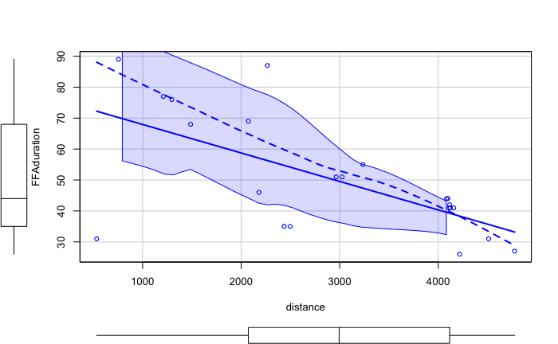

```r
scatterplot(FFAduration~distance, data=df)
```

> Linearity seems OK; might be an outlier, but we’ll see.

#### 6. Fit the model

```r
lm1<-lm(FFAduration~distance, data=df)
```

**How will you assess whether the model fits well?**

> Look at residuals as a first step, then also r^2. Look at influence measures, esp. Cook’s *D*

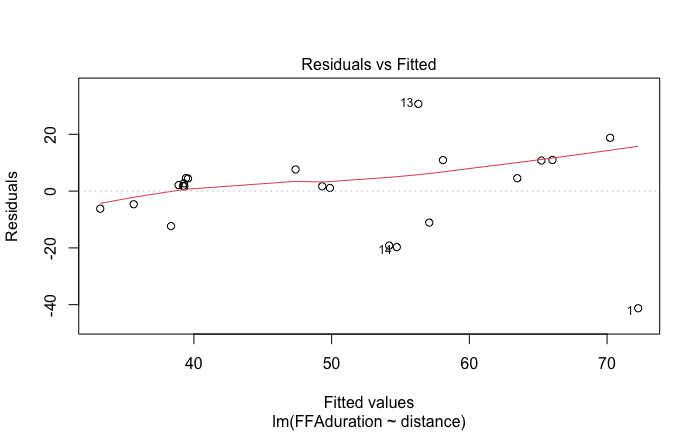

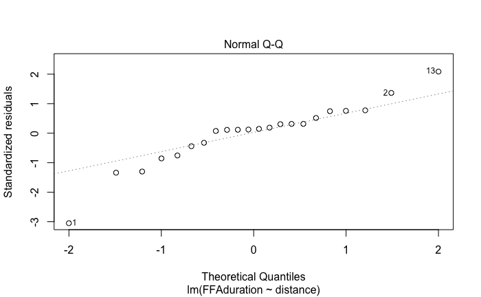

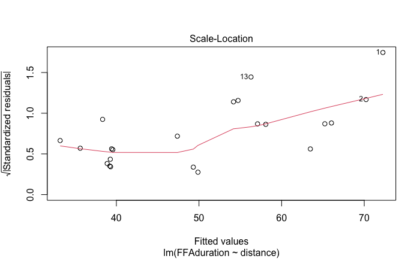

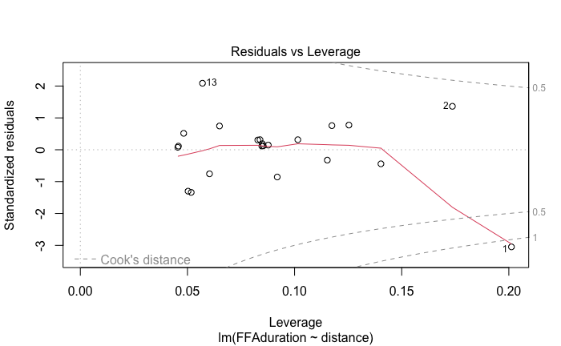

```r
plot(lm1)
```

```r
#influence.measures gives us detailed output, but augment gives more useful output
influence.measures(lm1)
```

```
Influence measures of
     lm(formula = FFAduration ~ distance, data = df) :
```

|  | dfb.1_ | dfb.dstn | dffit | cov.r | cook.d | hat | inf |
| --- | --- | --- | --- | --- | --- | --- | --- |
| 1 | -2.03183 | 1.793359 | -2.0383 | 0.398 | 1.170562 | 0.2012 | * |
| 2 | 0.63525 | -0.549867 | 0.6400 | 1.103 | 0.195502 | 0.1737 |  |
| 3 | 0.28246 | -0.231640 | 0.2901 | 1.192 | 0.042978 | 0.1254 |  |
| 5 | 0.26415 | -0.213756 | 0.2730 | 1.185 | 0.038115 | 0.1174 |  |
| 6 | 0.09823 | -0.076839 | 0.1034 | 1.221 | 0.005599 | 0.1015 |  |
| 7 | 0.16299 | -0.106456 | 0.1943 | 1.120 | 0.019308 | 0.0650 |  |
| 8 | -0.15219 | 0.093852 | -0.1892 | 1.113 | 0.018305 | 0.0603 |  |
| 13 | 0.43715 | -0.254860 | 0.5659 | 0.719 | 0.131806 | 0.0570 |  |
| 14 | -0.22274 | 0.111413 | -0.3193 | 0.969 | 0.048860 | 0.0518 |  |
| 15 | 0.00597 | 0.000601 | 0.0162 | 1.160 | 0.000137 | 0.0455 |  |

[output cut: 12 more lines]

```r
augment(lm1)
```

| .rownames | FFAduration | distance | .fitted | .resid | .hat | .sigma | .cooksd | .std.resid |
| --- | --- | --- | --- | --- | --- | --- | --- | --- |
| 1 | 31 | 534 | 72.3 | -41.26 | 0.2012 | 11.4 | 1.170562 | -3.0485 |
| 2 | 89 | 755 | 70.2 | 18.78 | 0.1737 | 14.8 | 0.195502 | 1.3640 |
| 3 | 77 | 1210 | 66.0 | 10.97 | 0.1254 | 15.3 | 0.042978 | 0.7744 |
| 5 | 76 | 1297 | 65.2 | 10.77 | 0.1174 | 15.3 | 0.038115 | 0.7570 |
| 6 | 68 | 1487 | 63.5 | 4.52 | 0.1015 | 15.5 | 0.005599 | 0.3148 |
| 7 | 69 | 2073 | 58.1 | 10.92 | 0.0650 | 15.3 | 0.019308 | 0.7455 |
| 8 | 46 | 2181 | 57.1 | -11.09 | 0.0603 | 15.3 | 0.018305 | -0.7554 |
| 13 | 87 | 2267 | 56.3 | 30.70 | 0.0570 | 13.7 | 0.131806 | 2.0880 |
| 14 | 35 | 2437 | 54.7 | -19.73 | 0.0518 | 14.8 | 0.048860 | -1.3381 |
| 15 | 51 | 2964 | 49.9 | 1.12 | 0.0455 | 15.5 | 0.000137 | 0.0759 |

[output cut: 12 more lines]

> Residual plot looks OK, but there is one concerning point (#1, an animal that made a short trip and didn’t stay long.

**Can you detect an effect of the predictor?**

> Now we’re (mostly) satisfied with assumptions, we can look at model fit. We’ll test whether slope differs from 0 as one way.

```r
summary(lm1)
```

```
Call:
lm(formula = FFAduration ~ distance, data = df)

Residuals:
   Min     1Q Median     3Q    Max
-41.26  -5.80   1.95   6.86  30.70

Coefficients:
            Estimate Std. Error t value Pr(>|t|)
(Intercept) 77.17751    7.99689    9.65  5.7e-09 ***
distance    -0.00921    0.00251   -3.67   0.0015 **
---
Signif. codes:  0 ‘***’ 0.001 ‘**’ 0.01 ‘*’ 0.05 ‘.’ 0.1 ‘ ’ 1

Residual standard error: 15.1 on 20 degrees of freedom
  (5 observations deleted due to missingness)
Multiple R-squared:  0.403, Adjusted R-squared:  0.373
F-statistic: 13.5 on 1 and 20 DF,  p-value: 0.00152
```

The summary options doesn’t give us confidence intervals around the parameter estimates, but we can get them easily.

```r
confint(lm1)
```

```
              2.5 %   97.5 %
(Intercept) 60.4963 93.85873
distance    -0.0144 -0.00398
```

**How do you measure the effect?**

> Use the hypothesis test as one way of justifying talking about an effect, or look at CI for slope to see if it includes 0. We’ll then use the slope (and it’s SE or CI) as a measure, and also use *r*^2 as a measure of how much variation has been explained.

#### 7. What do you conclude (including any cautions)

> As seals forage further from haulout sites, they spend less time in the foraging area. Roughly, for every 100 k further they travel, they spend a day less feeding. We might want to investigate the individual with high Cook’s D; without it, the slope would be steeper. At the very least, go to the original records and check that animal.

# B

Peake & Quinn (1993) investigated the relationship between the number of individuals and number of species (response variables) of invertebrates living in amongst clumps of mussels on a rocky intertidal shore and the area of those mussel clumps (predictor). You can get this data file here. >

The process for this exercise is identical to that for the elephant seal data set, but in this case we need to be looking at transformations of the variables. We’ve not shown the working here, as it’s pretty straightforward.

## Model 2 regression

# C

Dai et al (2019) examined the relationships between aboveground (AGB) and belowground (BGB) plant biomass from 80 sites across four types of grassland (temperate grassland, desert grassland, alpine meadow, meadow steppe) in a region of China. Their research questions did not distinguish response and predictor variables so they used reduced major axis (RMA) regression to determine the slopes of the relationships between log(ABG) and log(BGB) for each grassland type and compare these to a slope of 1, indicating an (isometric) allometric relationship.

#### 1. What is the biological question?

> What is the relationship between above- and below-ground biomass for four grassland habitats in China?

#### 2. Is the predictor continuous or categorical?

> Sort of a trick question, as we don’t have a clear predictor, but both variables are continuous

#### 3. Write out the linear model corresponding to this question.

> AGB = *β*<sub>0</sub> + *β*<sub>1</sub> BGB + *ε*

#### 4. What distribution do you expect the response variable to follow?

> Assume initially a normal distribution, but we may not have a clear idea

#### 5. What are the assumptions behind the statistical model you’ll fit?

> Normality (or some other specified distribution), variances constant across range of the other variable, linearity, independence (grassland samples are taken independently of each other)

**Are those assumptions satisfied?**

> Independence probably OK because of sampling strategy; the other assumptions can only be checked by fitting the model

```r
#Read in the data and assign it to an object df
library(readr)
df <- read_csv("data/dai.csv")
head(df,10)
```

| hab | bgb | agb | sprich | ...5 | ...6 | ...7 | ...8 | ...9 | ...10 | ...11 | ...12 | ...13 |
| --- | --- | --- | --- | --- | --- | --- | --- | --- | --- | --- | --- | --- |
| tempgrass | 1897 | 104.2 | 10.25 | NA | NA | NA | NA | NA | NA | NA | NA | NA |
| tempgrass | 1214 | 66.5 | 7.00 | NA | NA | NA | NA | NA | NA | NA | NA | NA |
| tempgrass | 1643 | 23.3 | 6.33 | NA | NA | NA | NA | NA | NA | NA | NA | NA |
| tempgrass | 3018 | 62.8 | 4.00 | NA | NA | NA | NA | NA | NA | NA | NA | NA |
| tempgrass | 628 | 29.0 | 6.33 | NA | NA | NA | NA | NA | NA | NA | NA | NA |
| tempgrass | 883 | 85.5 | 5.67 | NA | NA | NA | NA | NA | NA | NA | NA | NA |
| tempgrass | 4516 | 85.7 | 7.00 | NA | NA | NA | NA | NA | NA | NA | NA | NA |
| tempgrass | 891 | 59.3 | 11.33 | NA | NA | NA | NA | NA | NA | NA | NA | NA |
| tempgrass | 1089 | 34.5 | 8.00 | NA | NA | NA | NA | NA | NA | NA | NA | NA |
| tempgrass | 332 | 31.2 | 13.20 | NA | NA | NA | NA | NA | NA | NA | NA | NA |

Dai and colleagues were interested in the relationship for each grassland type. We’ll show the approach for just one of these. You can repeat the process for the others. In later chapters of the book, we also explore how to compare grassland types in a single model.

```r
df<-subset(df, hab=="tempgrass")
```

Do a scatterplot to check for linearity

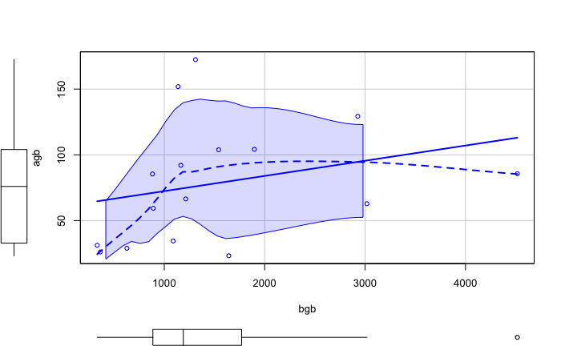

```r
scatterplot(agb~bgb, data=df)
```

> Linearity seems problematic - bgb looks skewed, with a couple of very large values. agb might also be, but less clearly. Let’s look at a log transformation.

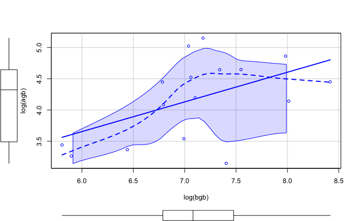

```r
scatterplot(log(agb)~log(bgb), data=df)
```

> This looks a bit better, though still a bit odd.

Log transform the two variables

```r
df$lbgb<-log(df$bgb)
df$lagb<-log(df$agb)
```

#### 6. Fit the model

```r
lm1 <- lmodel2(lbgb~lagb, data=df, range.y='interval', range.x='interval', nperm=1000)
lm1
```

```
Model II regression

Call: lmodel2(formula = lbgb ~ lagb, data = df, range.y = "interval", range.x = "interval", nperm = 1000)

n = 16   r = 0.515   r-square = 0.265
Parametric P-values:   2-tailed = 0.0411    1-tailed = 0.0206
Angle between the two OLS regression lines = 35.4 degrees

Permutation tests of OLS, MA, RMA slopes: 1-tailed, tail corresponding to sign
A permutation test of r is equivalent to a permutation test of the OLS slope
P-perm for SMA = NA because the SMA slope cannot be tested

Regression results
```

| Method | Intercept | Slope | Angle (degrees) | P-perm (1-tailed) |
| --- | --- | --- | --- | --- |
| OLS | 4.78 | 0.559 | 29.2 | 0.021 |
| MA | 2.22 | 1.169 | 49.5 | 0.021 |
| SMA | 2.58 | 1.084 | 47.3 | NA |
| RMA | 3.28 | 0.917 | 42.5 | 0.021 |

```
Confidence intervals
```

| Method | 2.5%-Intercept | 97.5%-Intercept | 2.5%-Slope | 97.5%-Slope |
| --- | --- | --- | --- | --- |
| OLS | 2.523 | 7.03 | 0.0258 | 1.09 |
| MA | -11.869 | 5.48 | 0.3911 | 4.54 |
| SMA | -0.169 | 4.29 | 0.6753 | 1.74 |
| RMA | -3.064 | 6.30 | 0.1941 | 2.43 |

```
Eigenvalues: 0.7 0.221

H statistic used for computing C.I. of MA: 0.222
```

**How will you assess whether the model fits well?**

> Look at residuals as a first step, then also r^2.

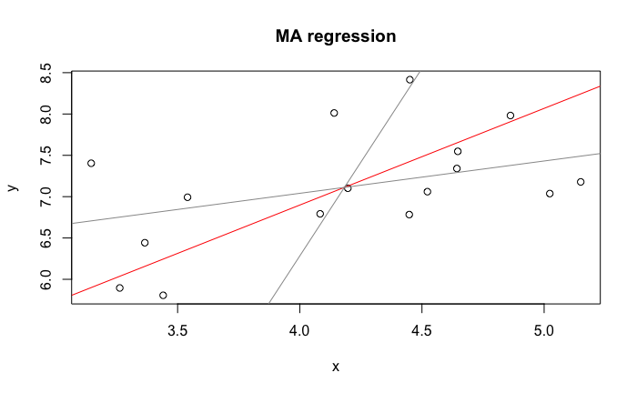

```r
plot(lm1)
```

**Can you detect an effect of the predictor?**

> Now we’re (mostly) satisfied with assumptions, we can look at model fit. The research question is about whether the slope is 1, so we could formally test wither it is, or we could look at the estimate of the slope and its confidence intervals, which we have above.

> The CI is 0.68 to 1.74, and the estimated slope 1.08 is very close.

**How do you measure the effect?**

> Look at CI for slope to see if it includes 1. We’ll then use the slope (and it’s SE or CI) as a measure, and also use *r*^2 as a measure of how much variation has been explained.

#### 7. What do you conclude (including any cautions)

> Above and below ground biomass is related, and logged biomasses are related, with a slope around 1. The relationship is a noisy one (r/^2 only 0.26)

# D

Vosteen et al (2016) examined patterns of production of honeydew by different races of pea aphids (*Acyrthosiphon pisum*) and how that attracts ovipositioning hoverflies (*Episyrphus balteatus*) to create enemy-free space for the aphids. They measured honeydew production (mg) over 24 hours by three races of aphids (representing the native hosts they were collected from: *Triflolium*, *Pisum*, *Medicago* races) on plants of their native hosts and also the universal host plant *Vicia faba* in a climate chamber. There were six combinations of aphid race and host (native vs universal) plant that Vosteen et al (2016) treated as a single factor. The data from this paper are available through [*datadryad*](https://datadryad.org/stash/dataset/doi:10.5061/dryad.37972) *.* For this question, the data set we’ll use is for Figure 2e. The authors’ analysis is provided and uses the data set …2e…collection.txt, but we want to do a different analysis in Chapter 7, so the file with additional factors is here.

> In the next Chapter’s exercises, we’ll return to this example and describe the terms in the linear model if this study was treated as a two-factor (aphid race and host plant)

#### 1. What is the biological question?

> The question is broadly about whether honeydew production by pea aphids varies with the combination of aphid race and kind of host.

#### 2. Is the predictor continuous or categorical?

> Categorical

#### 3. Write out the linear model corresponding to this question.

> honeydew = *μ* + aphid-plant<sub>*i*</sub> + *ε*

#### 4. What distribution do you expect the response variable to follow?

> Assume initially a normal distribution. We don’t have any specific information about the distribution, but have no reason to expect strongly skewed, etc.

#### 5. What are the assumptions behind the statistical model you’ll fit?

> Normality (or some other specified distribution) of error terms, variances constant across treatments, independence (aphid honeydew production measurements are independent of each other)

**Are those assumptions satisfied?**

> Independence probably OK because of aphids are assessed from physically separate races; the other assumptions can only be checked by fitting the model

```r
#Read in the data and assign it to an object df
df <- read_csv("data/vosteen.csv")
df$Treatment<-df$clone_plant_combination   #just get a simpler name for the predictor
head(df,10)
```

| clone_plant_combination | honeydew | clone | plant | hostplant | Treatment |
| --- | --- | --- | --- | --- | --- |
| T_Vicia | 1.08 | T | Vicia | Universal | T_Vicia |
| T_Vicia | 2.21 | T | Vicia | Universal | T_Vicia |
| T_Vicia | 2.63 | T | Vicia | Universal | T_Vicia |
| T_Vicia | 1.63 | T | Vicia | Universal | T_Vicia |
| T_Vicia | 3.51 | T | Vicia | Universal | T_Vicia |
| T_Vicia | 2.53 | T | Vicia | Universal | T_Vicia |
| T_Vicia | 2.92 | T | Vicia | Universal | T_Vicia |
| T_Vicia | 0.98 | T | Vicia | Universal | T_Vicia |
| T_Vicia | 2.39 | T | Vicia | Universal | T_Vicia |
| T_Vicia | 2.05 | T | Vicia | Universal | T_Vicia |

Do a quick boxplot to check variances, skew, etc.

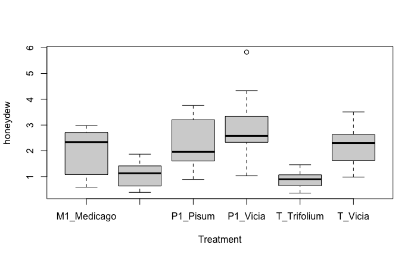

```r
boxplot(honeydew~Treatment, data=df)
```

#### 6. Fit the model

```r
lm1<-aov(honeydew~Treatment, data=df)
```

**How will you assess whether the model fits well?**

> Look at residuals as a first step

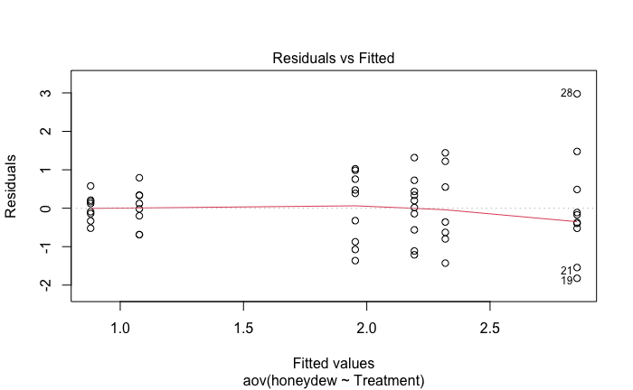

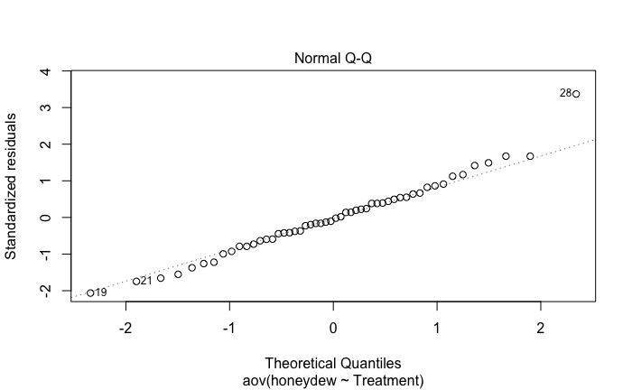

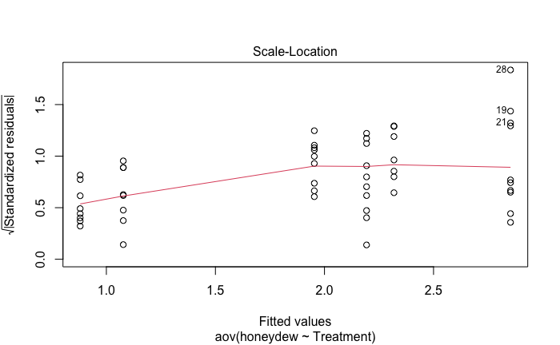

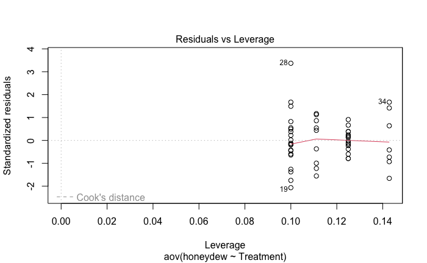

```r
plot(lm1)
```

> Residuals look OK. Possible greater spread with higher predicted values, but probably not of major concern.

**Can you detect an effect of the predictor?**

> Now we’re (mostly) satisfied with assumptions, we can look at model fit. We’ll test whether the treatments differ from each other.

```r
summary(lm1)
```

```
            Df Sum Sq Mean Sq F value  Pr(>F)
Treatment    5   24.9    4.98    5.75 0.00034 ***
Residuals   46   39.9    0.87
---
Signif. codes:  0 ‘***’ 0.001 ‘**’ 0.01 ‘*’ 0.05 ‘.’ 0.1 ‘ ’ 1
```

> We want a few things from this output: Determine and interpret the following: a. F-value for treatment: *5.75; 5 or 6 times more variation between treatments than within* b. P-value for main H<sub>0</sub>: *P = 0.0003*

> The summary options doesn’t give us confidence intervals around the parameter estimates, but we can get them easily.

```r
library(emmeans)
a<-emmeans(lm1, ~Treatment)
a
```

```
 Treatment   emmean    SE df lower.CL upper.CL
 M1_Medicago   1.95 0.310 46    1.329     2.58
 M1_Vicia      1.08 0.329 46    0.415     1.74
 P1_Pisum      2.32 0.352 46    1.610     3.03
 P1_Vicia      2.85 0.294 46    2.260     3.45
 T_Trifolium   0.88 0.329 46    0.217     1.54
 T_Vicia       2.19 0.294 46    1.600     2.79

Confidence level used: 0.95
```

```r
#convert to data frame to plot easily
a<-as.data.frame(a)
```

**How do you measure the effect?**

> Use the group means and their confidence intervals. It would be helpful to have a plot of means as well

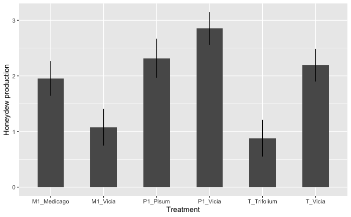

```r
ggplot(a, aes(x=Treatment,y=emmean))+
geom_bar(width = 0.5, position = position_dodge(), stat="summary")+
  geom_errorbar(aes(ymax=emmean+SE,ymin=emmean-SE), width=0)+
  labs(y="Honeydew production")
```

#### 7. What do you conclude (including any cautions)

> For this data set, we wouldn’t stop at the overall analysis of variance. To make detailed conclusions, we need to explore the differences among the group means in more detail. We could do it by inspection of means and CIs above, which suggests a complex pattern of production, depending on both aphid strain and plant host.

# E

Binning et al (2013) studied the effect of ectoparasitic isopods (*Anilocra nemipteri*) on the swimming ability of a tropical species of bream (*Scolopsis bilineatus*). They collected 18 unparasitized and 20 parasitized fish from Lizard Island on the Great Barrier Reef and created four treatment groups in the laboratory: eight unparasitized fish, 10 parasitized fish, 10 parasitized fish that had the parasites removed, and ten unparasitized fish that had model parasites made of plastic added. They recorded the swimming speed (body lengths per second) and oxygen consumption (mgO<sub>2</sub> per kg per hour) of each fish, in a respirometer. The data are available from [datadryad](https://datadryad.org/stash/dataset/doi:10.5061/dryad.r73v3). Within dryad, the dataset you want is “binning etal 2012 one way anova.txt”; in this dataset, SMR is Standard Metabolic Rate (O<sub>2</sub> consumption), AS = factorial aerobic scope, and Ucrit is swimming speed.

#### 1. What is the biological question?

> The question is broadly about the effects of parasites on swimming speed (or aerobic performance). We’ll focus on swimming speed. The experimental treatments are also designed to suggest a mechanism, e.g., using model parasites to ask whether any effect is just a hydrodynamic one.

#### 2. Is the predictor continuous or categorical?

> Categorical

#### 3. Write out the linear model corresponding to this question.

> speed = *μ* + parasite<sub>*i*</sub> + *ε*

#### 4. What distribution do you expect the response variable to follow?

> Assume initially a normal distribution. We don’t have any specific information about the distribution, but have no reason to expect strongly skewed, etc.

#### 5. What are the assumptions behind the statistical model you’ll fit?

> Normality (or some other specified distribution) of error terms, variances constant across treatments, independence (fish swim speeds are independent of each other)

**Are those assumptions satisfied?**

> Independence probably OK because of fish are assessed individually; the other assumptions can only be checked by fitting the model

```r
#Read in the data and assign it to an object df
df <- read_delim("data/binning.csv")
head(df,10)
```

| Fish | Treatment | SMR | MMR | AS | Ucrit |
| --- | --- | --- | --- | --- | --- |
| P10 | P | 110 | 536 | 4.86 | 3.79 |
| P12 | P | 140 | 471 | 3.36 | 3.66 |
| P27 | P | 136 | 573 | 4.22 | 2.47 |
| P42 | P | 140 | 380 | 2.70 | 3.65 |
| P15 | P | 121 | 562 | 4.66 | 3.52 |
| P23 | P | 108 | 376 | 3.48 | 3.39 |
| P26 | P | 119 | 535 | 4.49 | 3.74 |
| P37 | P | 153 | 495 | 3.24 | 3.37 |
| P72 | P | 101 | 430 | 4.26 | 3.36 |
| P75 | P | 134 | 435 | 3.24 | 3.68 |

Do a quick boxplot to check variances, skew, etc.

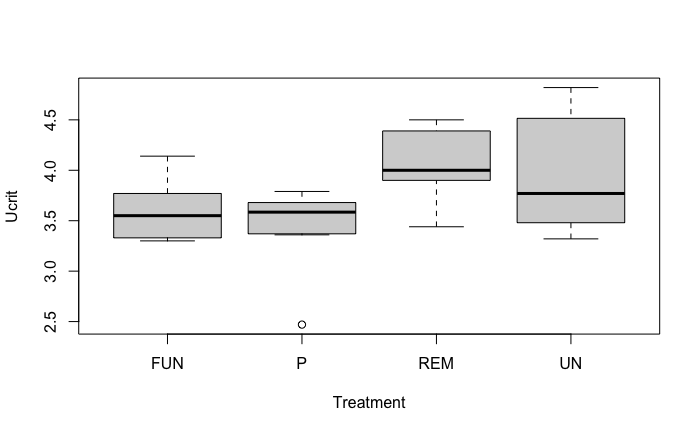

```r
boxplot(Ucrit~Treatment, data=df)
```

#### 6. Fit the model

```r
lm1<-aov(Ucrit~Treatment, data=df)
```

**How will you assess whether the model fits well?**

> Look at residuals as a first step, then also r^2. Look at influence measures, esp. Cook’s *D*

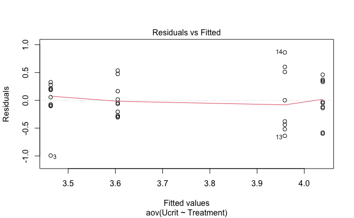

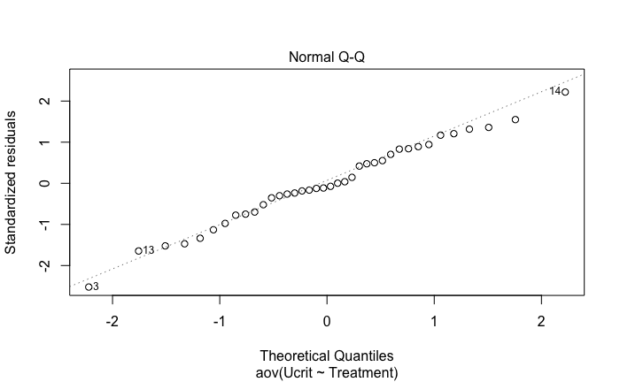

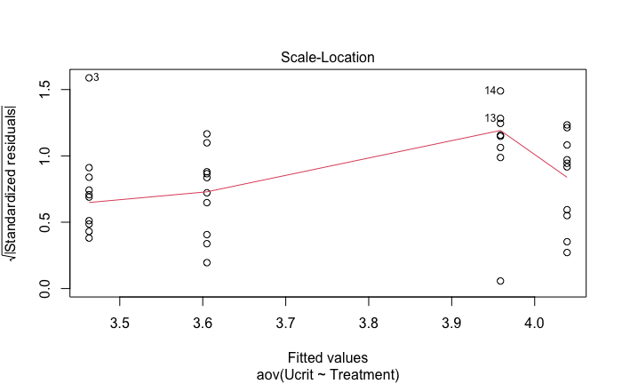

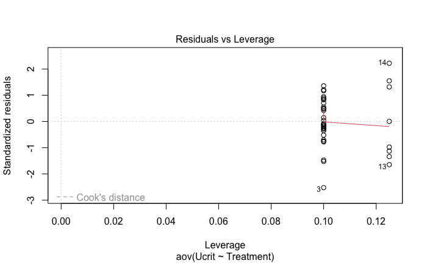

```r
plot(lm1)
```

Residuals look OK

**Can you detect an effect of the predictor?**

> Now we’re (mostly) satisfied with assumptions, we can look at model fit. We’ll test whether the treatments differ from each other.

```r
summary(lm1)
```

```
            Df Sum Sq Mean Sq F value Pr(>F)
Treatment    3   2.22   0.739    4.29  0.011 *
Residuals   34   5.85   0.172
---
Signif. codes:  0 ‘***’ 0.001 ‘**’ 0.01 ‘*’ 0.05 ‘.’ 0.1 ‘ ’ 1
```

> We want a few things from this output: Determine and interpret the following: a. F-value for treatment: *4.29; 4 times more variation between treatments than within* b. P-value for main H<sub>0</sub>: *P = 0.0113*

The summary options doesn’t give us confidence intervals around the parameter estimates, but we can get them easily.

```r
library(emmeans)
a<-emmeans(lm1, ~Treatment)
a
```

```
 Treatment emmean    SE df lower.CL upper.CL
 FUN         3.61 0.131 34     3.34     3.87
 P           3.46 0.131 34     3.20     3.73
 REM         4.04 0.131 34     3.77     4.31
 UN          3.96 0.147 34     3.66     4.26

Confidence level used: 0.95
```

```r
#convert to data frame to plot easily
a<-as.data.frame(a)
```

**How do you measure the effect?**

> Use the group means and their confidence intervals. It would be helpful to have a plot of means as well

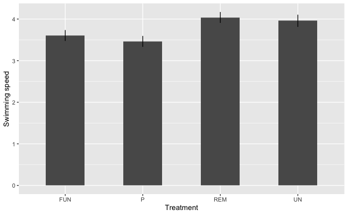

```r
ggplot(a, aes(x=Treatment,y=emmean))+
geom_bar(width = 0.5, position = position_dodge(), stat="summary")+
  geom_errorbar(aes(ymax=emmean+SE,ymin=emmean-SE), width=0)+
  labs(y="Swimming speed")
```

#### 7. What do you conclude (including any cautions)

> For this data set, we wouldn’t stop at the overall analysis of variance. To make detailed conclusions, we need to explore the differences among the group means in more detail. We could do it by inspection of means and CIs above, which suggests that swimming speed is reduced (by 10-15%) when parasites or functional mimics are present, compared to unparasitized fish and those from which parasites were removed. We could have done an unplanned comparison (e.g. Tukey’s test) or a planned comparison, possibly with the comparisons REM=UN (seeing if history of parasitism is important), FUN=P (seeing if live parasite is important) then (FUN+P)=(REM+UN). There may be other sequences of planned comparisons that make sense.

## References

Binning, S. A., D. G. Roche, and C. Layton. 2013. Ectoparasites increase swimming costs in a coral reef fish. *Biology Letters* **9**:20120927. doi:10.1098/rsbl.2012.0927

Dai, L., X. Guo, X. Ke, Y. Lan, F. Zhang, Y. Li, L. Lin, Q. Li, G. Cao, B. Fan, D. Qian, H. Zhou, and Y. Du. 2019. Biomass allocation and productivity–richness relationship across four grassland types at the Qinghai Plateau. *Ecology and Evolution* **10**:506-516. doi:10.1002/ece3.5920

Le Boeuf, B. J., D. E. Crocker, D. P. Costa, S. B. Blackwell, P. M. Webb, and D. S. Houser. 2000. Foraging ecology of northern elephant seals. *Ecological Monographs* **70**:353-382. doi:10.1890/0012-9615(2000)070[0353:Feones]2.0.Co;2

Peake, A. J., and G. P. Quinn. 1993. Temporal variation in species-area curves for invertebrates in clumps of an intertidal mussel. *Ecography* **16**:269-277

Vosteen, I., J. Gershenzon, and G. Kunert. 2016. Hoverfly preference for high honeydew amounts creates enemy-free space for aphids colonizing novel host plants. *J Anim Ecol* **85**:1286-97. doi:10.1111/1365-2656.12564